# chapter_4.Rmd

Jrose

2022-04-02

# Chapter 4

Here I am diving into the AMES housing data using R for the first time!

```r
library(modeldata) # This is also loaded by the tidymodels package
data(ames)

# or, in one line:
data(ames, package = "modeldata")

dim(ames)
```

```
## [1] 2930   74
```

```
#> [1] 2930   74
```

### Exploring important features

Outcome we want to predict

```r
library(tidymodels)
```

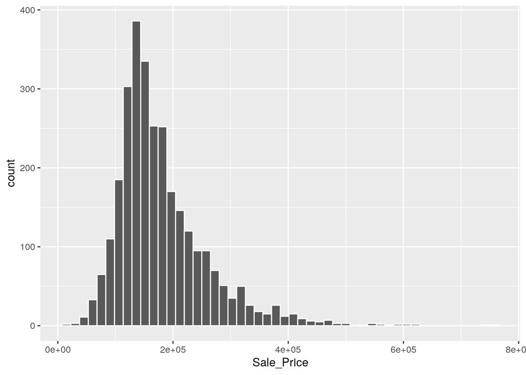

```r
tidymodels_prefer()

ggplot(ames, aes(x = Sale_Price)) +
  geom_histogram(bins = 50, col= "white")
```

Since this feature is so heavily skewed towards the higher end the authors recommend log transforming for two reasons:

- No chance of predicting a negative price for a house
- Variance stabilization

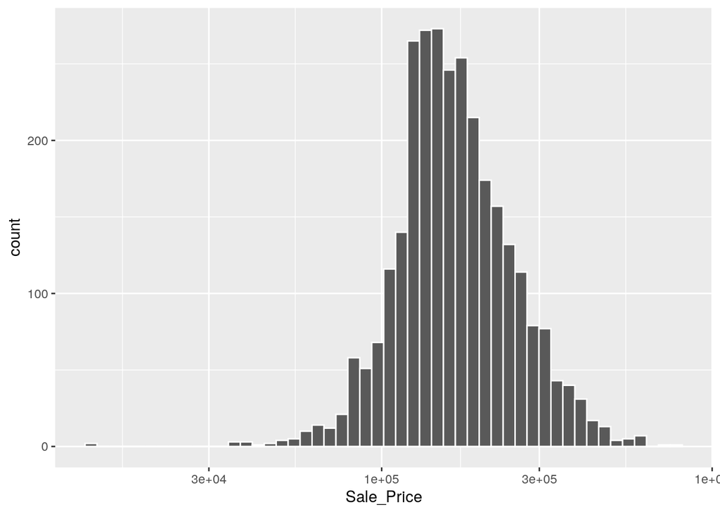

```r
ggplot(ames, aes(x = Sale_Price)) +
  geom_histogram(bins = 50, col= "white") +
  scale_x_log10()
```

```r
ames <- ames %>% mutate(Sale_Price = log10(Sale_Price))
```

Let’s look closer at the other features here:

```r
str(ames)
```

```
## tibble [2,930 × 74] (S3: tbl_df/tbl/data.frame)
##  $ MS_SubClass       : Factor w/ 16 levels "One_Story_1946_and_Newer_All_Styles",..: 1 1 1 1 6 6 12 12 12 6 ...
##  $ MS_Zoning         : Factor w/ 7 levels "Floating_Village_Residential",..: 3 2 3 3 3 3 3 3 3 3 ...
##  $ Lot_Frontage      : num [1:2930] 141 80 81 93 74 78 41 43 39 60 ...
##  $ Lot_Area          : int [1:2930] 31770 11622 14267 11160 13830 9978 4920 5005 5389 7500 ...
##  $ Street            : Factor w/ 2 levels "Grvl","Pave": 2 2 2 2 2 2 2 2 2 2 ...
##  $ Alley             : Factor w/ 3 levels "Gravel","No_Alley_Access",..: 2 2 2 2 2 2 2 2 2 2 ...
##  $ Lot_Shape         : Factor w/ 4 levels "Regular","Slightly_Irregular",..: 2 1 2 1 2 2 1 2 2 1 ...
##  $ Land_Contour      : Factor w/ 4 levels "Bnk","HLS","Low",..: 4 4 4 4 4 4 4 2 4 4 ...
##  $ Utilities         : Factor w/ 3 levels "AllPub","NoSeWa",..: 1 1 1 1 1 1 1 1 1 1 ...
##  $ Lot_Config        : Factor w/ 5 levels "Corner","CulDSac",..: 1 5 1 1 5 5 5 5 5 5 ...
##  $ Land_Slope        : Factor w/ 3 levels "Gtl","Mod","Sev": 1 1 1 1 1 1 1 1 1 1 ...
##  $ Neighborhood      : Factor w/ 29 levels "North_Ames","College_Creek",..: 1 1 1 1 7 7 17 17 17 7 ...
##  $ Condition_1       : Factor w/ 9 levels "Artery","Feedr",..: 3 2 3 3 3 3 3 3 3 3 ...
##  $ Condition_2       : Factor w/ 8 levels "Artery","Feedr",..: 3 3 3 3 3 3 3 3 3 3 ...
```

[output cut: 60 more lines]

# Chapter 5

Spending our data

- When data is plentiful it is wise to “allocate specific subsets of data for different tasks” (i.e. model parameter estimation)

### 5.1 Splitting data

Training and Test sets

Training:

- Usually the majority of data
- Sandbox for model building

Test:

- Held in reserve until 1-2 models are chosen
- Final arbiter to determine efficacy of the model

#### Random sampling

Use `rsample::intial_split()`.

Takes a dataframe as input, plus proportion of groups

```r
library(tidymodels)
tidymodels_prefer()

# Set the random number stream using `set.seed()` so that the results can be
# reproduced later.
set.seed(501)

# Save the split information for an 80/20 split of the data
ames_split <- initial_split(ames, prop = 0.80)
ames_split
```

```
## <Analysis/Assess/Total>
## <2344/586/2930>
```

```
#> <Analysis/Assess/Total>
#> <2344/586/2930>
```

Data printed shows:

#Data points in training/#Data points in test/Size of original pool

Initial split only gives the locations of splits. Need to use the following to create actual subsets of data as data frames.

```r
ames_train <- training(ames_split)
ames_test  <-  testing(ames_split)

dim(ames_train)
```

```
## [1] 2344   74
```

##### Stratified Random Sampling

Better when there is an imbalance of classification in data

Split of data is conducted separately within each class

Sometimes you may want to stratify based on quartiles of the predicted variable.

Use the strata parameter in the initial_split function to do this

**Only a single column can be used this way**

```r
set.seed(502)
ames_split <- initial_split(ames, prop = 0.80, strata = Sale_Price)
ames_train <- training(ames_split)
ames_test  <-  testing(ames_split)

dim(ames_train)
```

```
## [1] 2342   74
```

When is random sampling not the best?

- When data has a time component (i.e. time series)
  - Instead use most recent data as test
  - Use `initial_time_split()`

### 5.2 Validation Set

Another subset of the data used to test model during parameter estimation.

You can take this from either the training or test subsets

### 5.3 Multi-level data

You need to think about what the “independent experimental unit” is in your data set. Here it is pretty clear that each house could be considered independent, however it becomes more difficult when you start dealing with time series or multiple samples from the same source (i.e. cell types from one individual)

**You need to make sure you split your data *at the level* of experimental units**

### 5.4 Other considerations

**Information leakage** is when data outside of the training set are used in the modeling process

**Keep the test set quarantined**